[figure not shown]

# Assessment Unit Summary

| AU ID: | AK_B_1010204_001 |
| --- | --- |
| AU Type: | Beach |

[interactive chart not shown]

### Monitoring Location(s) Summary

| Monitoring Location | Latitude | Longitude |
| --- | --- | --- |
| 21AKBCH-AK909574 | 55.44864 | -131.8314 |

### Assessment Unit Location within Alaska

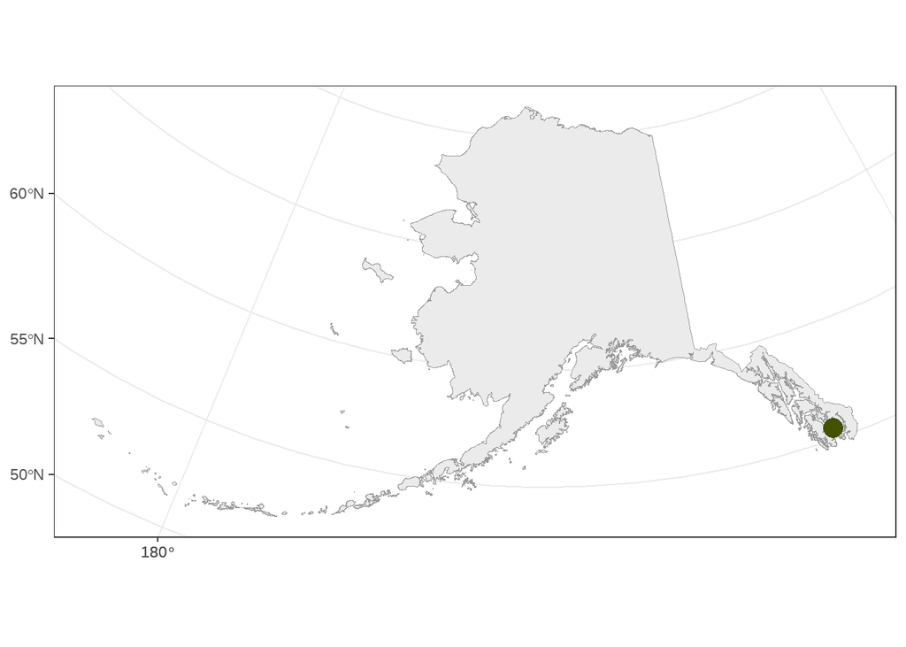

### Designated Uses and Attainment

| Use: | Use Category: |
| --- | --- |
| Aquatic Life | 5 |
| Primary Contact Recreation | 5 |
| Secondary Contact Recreation | 2 |
| Water Supply | 5 |

###### **Categories 1 and 2:** Waters for which there is enough information to determine that water quality standards are attained for all or some of their designated uses.

###### **Category 3:** Waters for which there is not enough information to determine their status.

###### **Category 4:** Waters that are impaired, but have one of several different types of waterbody recovery plans.

###### **Category 5:** Waters that are impaired and do not yet have waterbody recovery plans. Also known as 303(d) list impaired waters.

### Attainment by Parameter

| Parameter | Designated Use | Attainment | # of Samples | Chronic/Acute | Magnitude | Frequency | Duration |
| --- | --- | --- | --- | --- | --- | --- | --- |
| Enterococci | Primary Contact Recreation | Exceeding | 79 | NA | 35.0 | Not to exceed | 30-day period |
| Enterococci | Primary Contact Recreation | Exceeding | 79 | NA | 130.0 | 10% of samples | Water year average |
| Fecal Coliform | Aquatic Life | Exceeding | 84 | NA | 28.0 | 10% of samples | Water year average |
| Fecal Coliform | Aquatic Life | Exceeding | 84 | NA | 31.0 | 10% of samples | Water year average |
| Fecal Coliform | Aquatic Life | Exceeding | 84 | NA | 43.0 | 10% of samples | Water year average |
| Fecal Coliform | Aquatic Life | Exceeding | 84 | NA | 49.0 | 10% of samples | Water year average |
| Fecal Coliform | Aquatic Life | Exceeding | 84 | NA | 14.0 | Not to exceed | Water year average |
| Fecal Coliform | Secondary Contact Recreation | Not exceeding | 84 | NA | 200.0 | Not to exceed | 30-day period |
| Fecal Coliform | Secondary Contact Recreation | Not exceeding | 84 | NA | 400.0 | 10% of samples | Water year average |
| Fecal Coliform | Water Supply | Exceeding | 84 | NA | 20.0 | Not to exceed | 30-day period |
| Fecal Coliform | Water Supply | Exceeding | 84 | NA | 40.0 | 10% of samples | Water year average |
| Fecal Coliform | Water Supply | Not exceeding | 84 | NA | 200.0 | Not to exceed | 30-day period |
| Fecal Coliform | Water Supply | Not exceeding | 84 | NA | 400.0 | 10% of samples | Water year average |
| Turbidity | Primary Contact Recreation | Not exceeding | 26 | NA | 25.0 | Not to exceed | 24-hour average |
| Turbidity | Secondary Contact Recreation | Not exceeding | 26 | NA | 25.0 | Not to exceed | 24-hour average |
| Turbidity | Water Supply | Not exceeding | 26 | NA | 25.0 | Not to exceed | 24-hour average |
| pH | Aquatic Life | Not exceeding | 25 | NA | 6.5 | 10% | Daily minimum |
| pH | Aquatic Life | Not exceeding | 25 | NA | 8.5 | 10% | Daily maximum |
| pH | Aquatic Life | Not exceeding | 25 | NA | 6.0 | 10% | Daily minimum |
| pH | Primary Contact Recreation | Not exceeding | 25 | NA | 6.0 | 10% | Daily minimum |
| pH | Primary Contact Recreation | Not exceeding | 25 | NA | 8.5 | 10% | Daily maximum |
| pH | Secondary Contact Recreation | Not exceeding | 25 | NA | 5.0 | 10% | Daily minimum |
| pH | Secondary Contact Recreation | Not exceeding | 25 | NA | 9.0 | 10% | Daily maximum |
| pH | Water Supply | Not exceeding | 25 | NA | 6.0 | 10% | Daily minimum |
| pH | Water Supply | Not exceeding | 25 | NA | 8.5 | 10% | Daily maximum |
| pH | Water Supply | Not exceeding | 25 | NA | 5.0 | 10% | Daily minimum |
| pH | Water Supply | Not exceeding | 25 | NA | 9.0 | 10% | Daily maximum |

###### **Parameter:** Qualitative or quantitative measurements of physical, chemical, or biological attributes such as temperatures, metals, or bacteria.

###### **Designated Use:** Water quality goals of a waterbody or portion thereof, in part, by designating the use or uses to be made of the water.

###### **Attainment:** Achieving attainment means that a waterbody is supporting all designated uses for the pollutant parameters evaluated. Impairement means that a waterbody is persistently exceeding criteria for one or more pollutants and not supporting all designated uses.

###### **Acute/Chronic:** Duration periods and frequency thresholds for toxic pollutants for their protection of aquatic life and human health vary depending on short term (acute) or longer-term (chronic) exposure.

###### **Magnitude:** Describes the allowable maximum or minimum numeric concentration of a pollutant determined to meet water quality standards and be protective of the designated use.

###### **Frequency:** Describes the allowable number of times a water quality criterion can be exceeded before water quality standards are not met and an impairment of the designated use occurs.

###### **Duration:** Describes the length of time a pollutant may be present and potentially impacting a designated use before the criterion is considered exceeded and water quality standards are not met.

### Distribution of Parameters

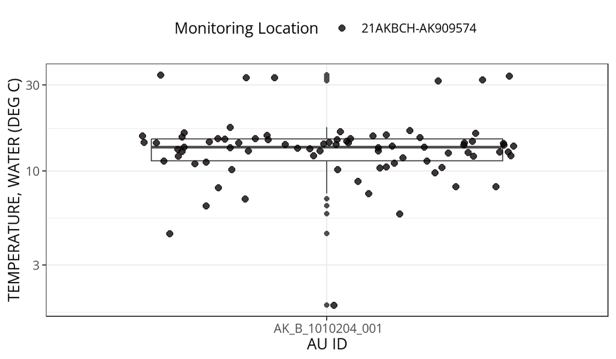

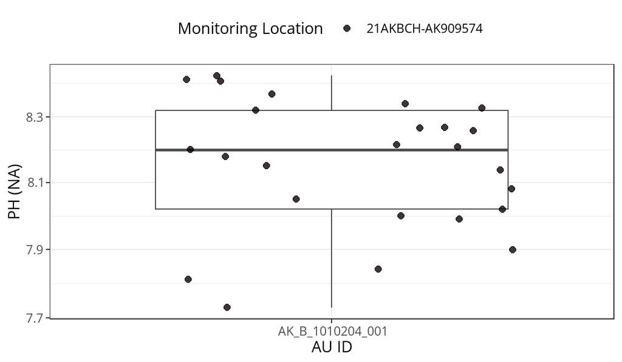

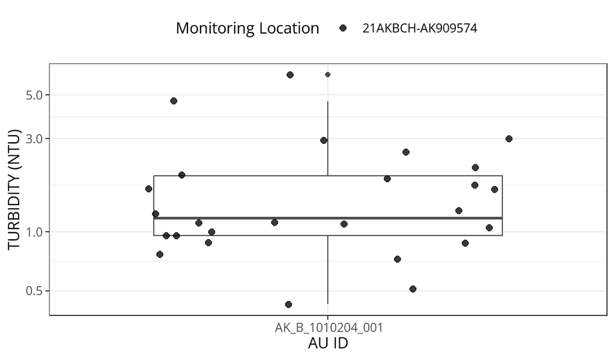

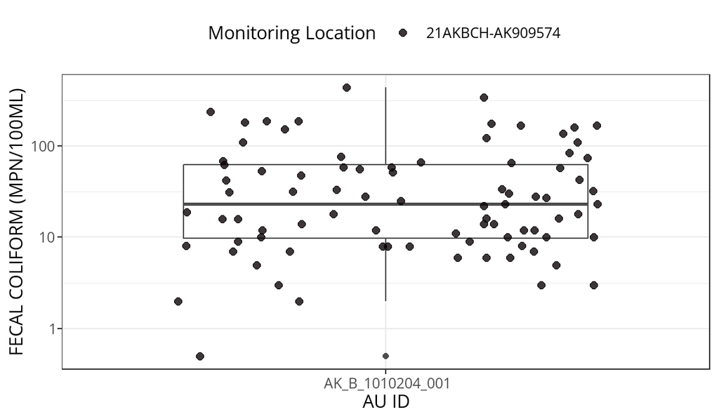

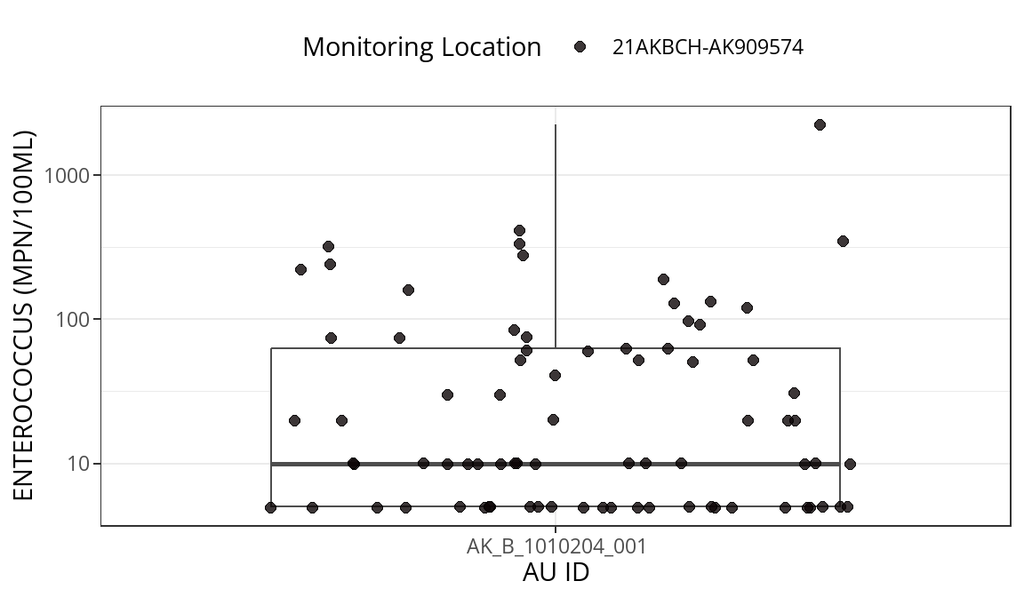

### Parameter Specific Time Series

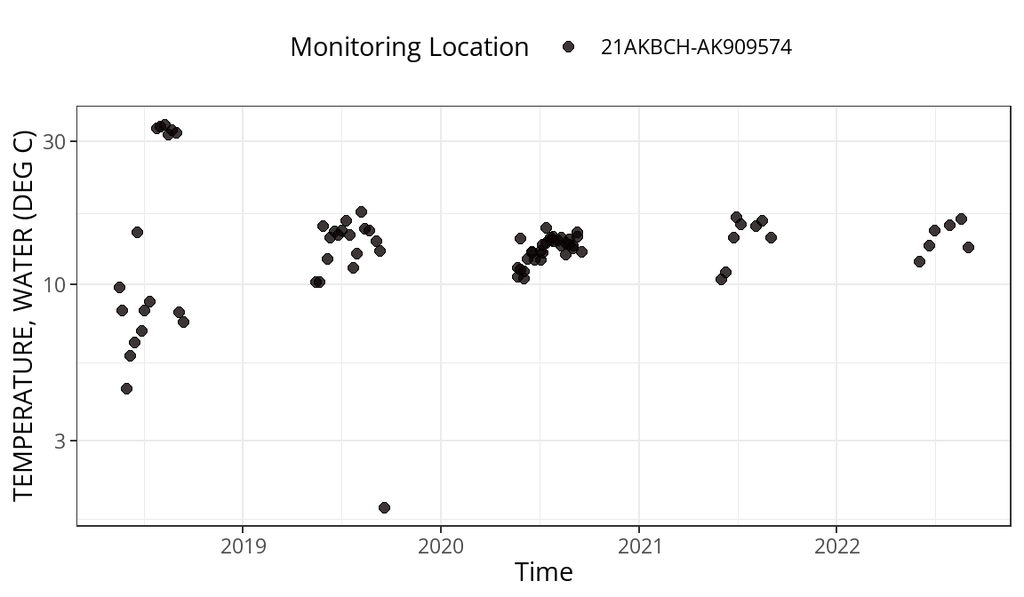

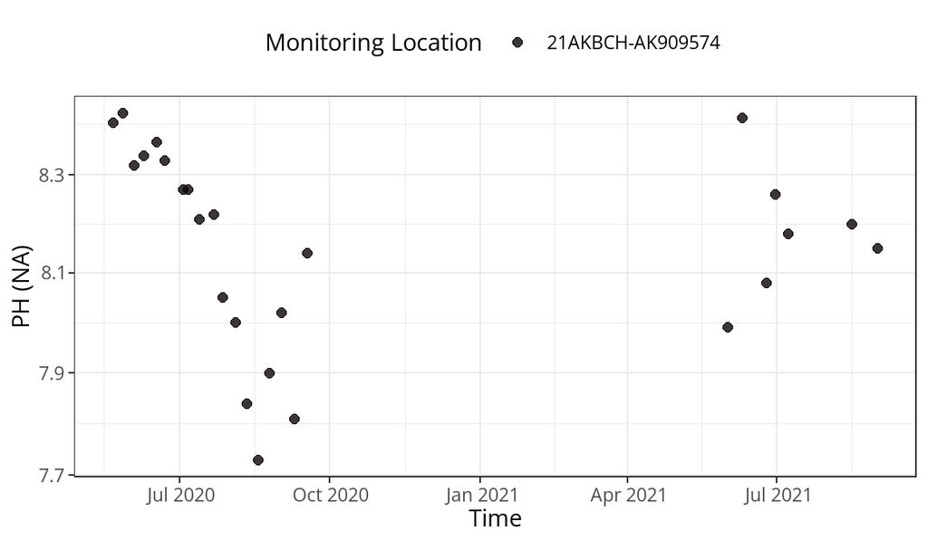

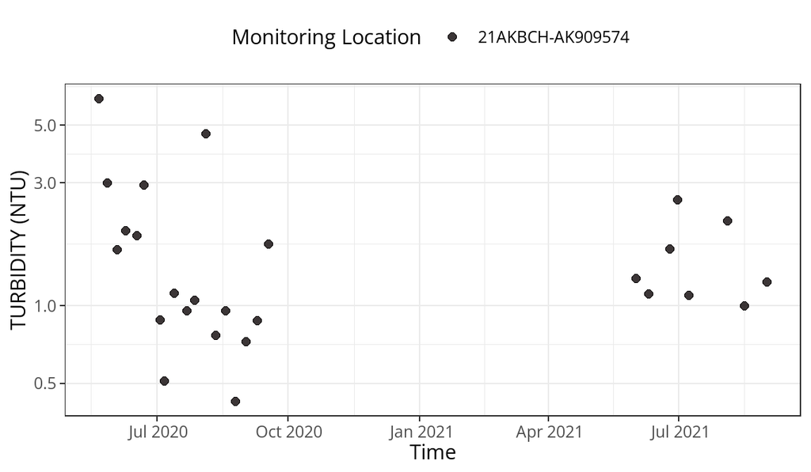

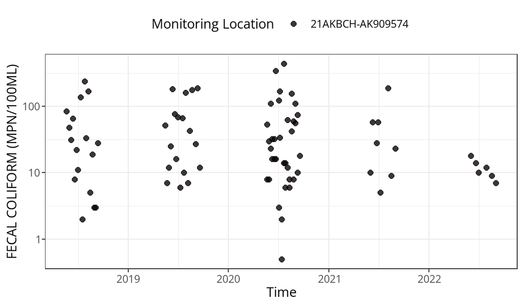

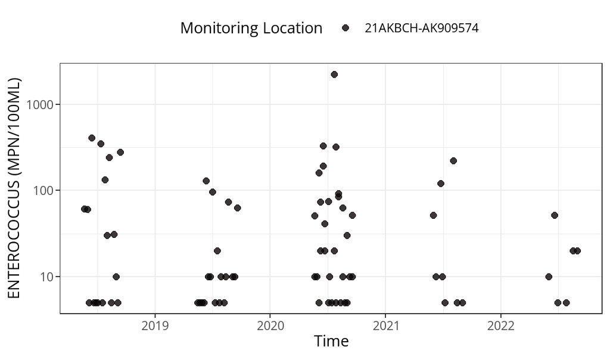